# Functional Trait & Diversity Models

Maggie Klope

10/7/2020

## GLMs for individual species change

- Does not include block because I only have the mean for each species at each plot
- Some species are present in all climate/treatment, but some are not
- Some species could be done with an lm after a log transformation

### Models:

**What is the effect of climate and grazing on individual species trait changes?**

`glm(trait ~ Climate * Treatment, family = gaussian)`

- planning to do for LA, SLA, and LDMC (from field collection in 2019) for a subset of species
- could do for seed mass and leaf N, but those values would be from TRY Database
- species chosen as those that are present across as many climate/treatment combinations as possible
- unfortunately, I scanned and weighed the leaves together to get averages, so I have lost the ability to add block to my models
- need to think of how I would deal with multiple comparisons (bonferroni correction?)

#### Bromus diandrus

- invasive grass
- no difference in LA between climate treatments

```r
#Bromus diandrus (grass)
bro_dia <- traits_19[traits_19$Species == "Bromus diandrus",]
glm_bro_dia <- glmmTMB(data = bro_dia, LA ~ Climate * Treatment, family = gaussian)
dredge(glm_bro_dia) #removed treatment from model
```

```
## Fixed terms are "cond((Int))" and "disp((Int))"
```

```
## Global model call: glmmTMB(formula = LA ~ Climate * Treatment, data = bro_dia, family = gaussian,
##     ziformula = ~0, dispformula = ~1)
## ---
## Model selection table
##   cnd((Int)) dsp((Int)) cnd(Clm) cnd(Trt) cnd(Clm:Trt) df   logLik  AICc delta
## 1      339.0          +                                 2 -145.996 296.6  0.00
## 2      416.7          +        +                        4 -143.894 297.9  1.33
## 3      350.9          +                 +               4 -145.375 300.9  4.29
## 4      419.3          +        +        +               6 -143.434 303.8  7.25
## 8      450.2          +        +        +            + 10 -141.506 319.9 23.37
##   weight
## 1  0.603
## 2  0.310
## 3  0.071
## 4  0.016
## 8  0.000
## Models ranked by AICc(x)
```

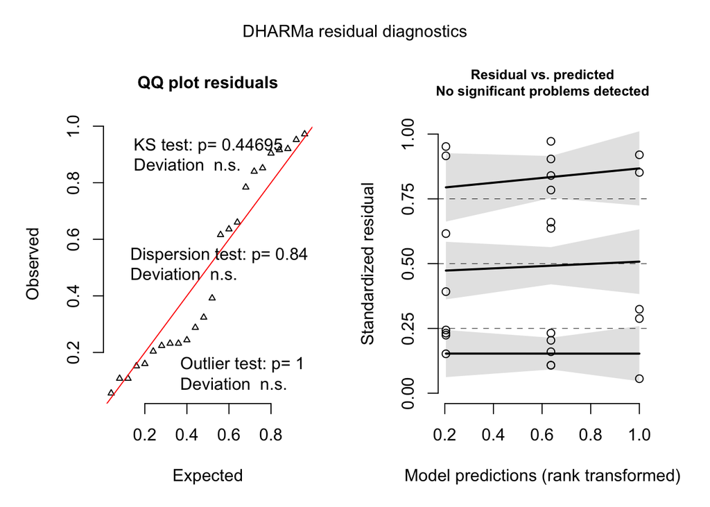

```
## Object of Class DHARMa with simulated residuals based on 250 simulations with refit = FALSE . See ?DHARMa::simulateResiduals for help.
##
## Scaled residual values: 0.056 0.92 0.324 0.288 0.852 0.16 0.904 0.66 0.84 0.232 0.972 0.784 0.636 0.108 0.204 0.108 0.952 0.224 0.244 0.232 ...
```

```r
glm_bro_dia <- glmmTMB(data = bro_dia, LA ~ Climate, family = gaussian)

simulateResiduals(glm_bro_dia, plot= T)
```

```r
shapiro.test(residuals(glm_bro_dia)) # barely normal
```

```
##
##  Shapiro-Wilk normality test
##
## data:  residuals(glm_bro_dia)
## W = 0.91849, p-value = 0.0541
```

```r
summary(glm_bro_dia)
```

```
##  Family: gaussian  ( identity )
## Formula:          LA ~ Climate
## Data: bro_dia
##
##      AIC      BIC   logLik deviance df.resid
##    295.8    300.5   -143.9    287.8       20
##
##
## Dispersion estimate for gaussian family (sigma^2): 9.45e+03
##
## Conditional model:
##                     Estimate Std. Error z value Pr(>|z|)
## (Intercept)           416.73      43.46   9.588   <2e-16 ***
## ClimateIntermediate   -84.08      52.42  -1.604   0.1087
## ClimateMesic         -117.63      55.41  -2.123   0.0337 *
## ---
## Signif. codes:  0 '***' 0.001 '**' 0.01 '*' 0.05 '.' 0.1 ' ' 1
```

```r
bro_dia_em <- emmeans(glm_bro_dia, ~Climate)
pairs(bro_dia_em) #model says that mesic is significantly lower than Arid, but that doesn't show when I use emmeans
```

```
##  contrast             estimate   SE df t.ratio p.value
##  Arid - Intermediate      84.1 52.4 20 1.604   0.2671
##  Arid - Mesic            117.6 55.4 20 2.123   0.1104
##  Intermediate - Mesic     33.5 45.2 20 0.743   0.7413
##
## P value adjustment: tukey method for comparing a family of 3 estimates
```

#### Festuca myuros

- non-native grass
- LA significantly higher between Arid-Intermediate and Arid-Mesic

```r
# Festuca myuros (grass)
fes_myu <- traits_19[traits_19$Species == "Festuca myuros",]
# glm_fes_myu <- glmmTMB(data = fes_myu, LA ~ Climate * Treatment,  family = gaussian) #convergence
glm_fes_myu <- glmmTMB(data = fes_myu, LA ~ Climate + Treatment,  family = gaussian)
dredge(glm_fes_myu) # remove treatment from model
```

```
## Fixed terms are "cond((Int))" and "disp((Int))"
```

```
## Global model call: glmmTMB(formula = LA ~ Climate + Treatment, data = fes_myu, family = gaussian,
##     ziformula = ~0, dispformula = ~1)
## ---
## Model selection table
##   cnd((Int)) dsp((Int)) cnd(Clm) cnd(Trt) df  logLik  AICc delta weight
## 2      66.02          +        +           4 -74.356 160.0  0.00  0.951
## 1      43.63          +                    2 -81.094 167.0  7.00  0.029
## 4      68.39          +        +        +  6 -73.714 167.8  7.78  0.019
## 3      43.12          +                 +  4 -81.068 173.5 13.42  0.001
## Models ranked by AICc(x)
```

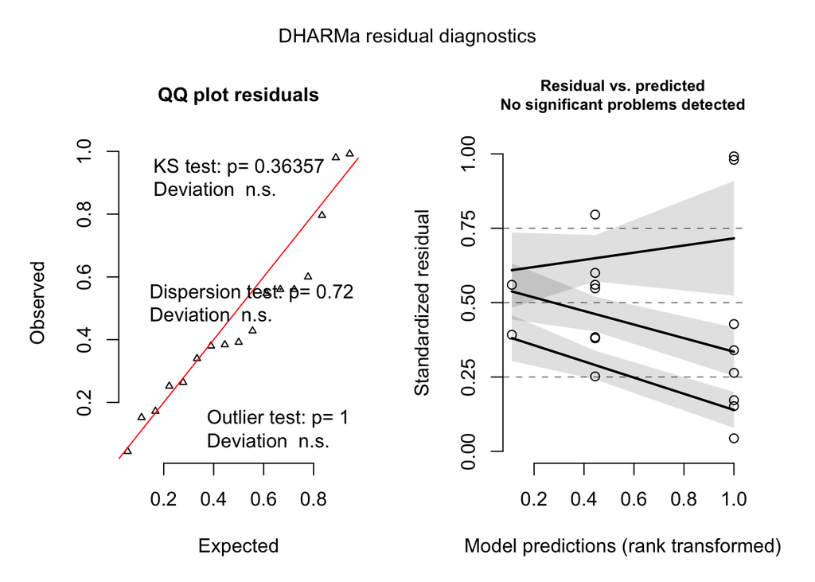

```
## Object of Class DHARMa with simulated residuals based on 250 simulations with refit = FALSE . See ?DHARMa::simulateResiduals for help.
##
## Scaled residual values: 0.34 0.264 0.98 0.172 0.152 0.044 0.992 0.428 0.384 0.56 0.252 0.796 0.548 0.38 0.6 0.56 0.392
```

```r
glm_fes_myu <- glmmTMB(data = fes_myu, LA ~ Climate,  family = gaussian)

simulateResiduals(glm_fes_myu, plot=T)
```

```r
shapiro.test(residuals(glm_fes_myu)) #not normal
```

```
##
##  Shapiro-Wilk normality test
##
## data:  residuals(glm_fes_myu)
## W = 0.87849, p-value = 0.03005
```

```r
#log LA
fes_myu <- fes_myu %>%
  mutate(log_LA = log(LA))

log_fes_myu <- glmmTMB(data = fes_myu, log_LA ~ Climate + Treatment,  family = gaussian)
dredge(log_fes_myu) #drop treatment
```

```
## Fixed terms are "cond((Int))" and "disp((Int))"
```

```
## Global model call: glmmTMB(formula = log_LA ~ Climate + Treatment, data = fes_myu,
##     family = gaussian, ziformula = ~0, dispformula = ~1)
## ---
## Model selection table
##   cnd((Int)) dsp((Int)) cnd(Clm) cnd(Trt) df  logLik AICc delta weight
## 2      4.117          +        +           4  -6.213 23.8  0.00  0.987
## 4      4.143          +        +        +  6  -6.184 32.8  9.01  0.011
## 1      3.585          +                    2 -15.742 36.3 12.58  0.002
## 3      3.565          +                 +  4 -15.604 42.5 18.78  0.000
## Models ranked by AICc(x)
```

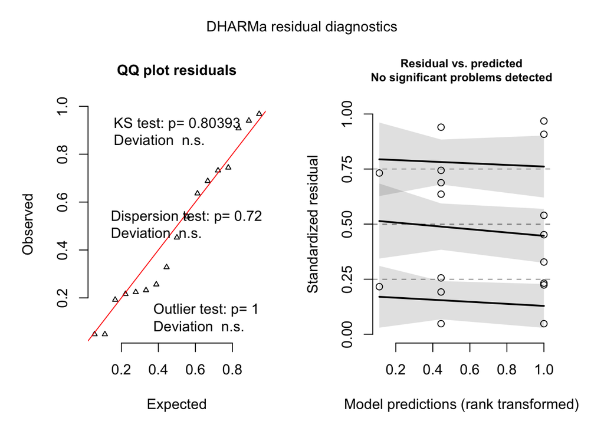

```
## Object of Class DHARMa with simulated residuals based on 250 simulations with refit = FALSE . See ?DHARMa::simulateResiduals for help.
##
## Scaled residual values: 0.452 0.328 0.908 0.224 0.232 0.048 0.968 0.54 0.256 0.636 0.048 0.94 0.688 0.192 0.744 0.732 0.216
```

```r
log_fes_myu <- glmmTMB(data = fes_myu, log_LA ~ Climate,  family = gaussian)

simulateResiduals(log_fes_myu, plot=T)
```

```r
shapiro.test(residuals(log_fes_myu)) #normal
```

```
##
##  Shapiro-Wilk normality test
##
## data:  residuals(log_fes_myu)
## W = 0.95103, p-value = 0.4729
```

```r
summary(log_fes_myu)
```

```
##  Family: gaussian  ( identity )
## Formula:          log_LA ~ Climate
## Data: fes_myu
##
##      AIC      BIC   logLik deviance df.resid
##     20.4     23.8     -6.2     12.4       13
##
##
## Dispersion estimate for gaussian family (sigma^2): 0.122
##
## Conditional model:
##                     Estimate Std. Error z value Pr(>|z|)
## (Intercept)           4.1171     0.1233   33.39  < 2e-16 ***
## ClimateIntermediate  -0.9912     0.1805   -5.49 3.97e-08 ***
## ClimateMesic         -1.0492     0.2757   -3.81 0.000141 ***
## ---
## Signif. codes:  0 '***' 0.001 '**' 0.01 '*' 0.05 '.' 0.1 ' ' 1
```

```r
log_fes_myu_em <- emmeans(log_fes_myu, ~Climate)
pairs(log_fes_myu_em)
```

```
##  contrast             estimate    SE df t.ratio p.value
##  Arid - Intermediate    0.9912 0.180 13 5.492   0.0003
##  Arid - Mesic           1.0492 0.276 13 3.806   0.0058
##  Intermediate - Mesic   0.0579 0.280 13 0.207   0.9766
##
## P value adjustment: tukey method for comparing a family of 3 estimates
```

```r
# Bromus hordeacous (grass)
glm_bro_ho <- glm(data = traits_19[traits_19$Species == "Bromus hordeaceus",], LA ~ Climate * Treatment, family = gaussian)

# Bromus tectorum (grass)
glm_bro_tec <- glm(data = traits_19[traits_19$Species == "Bromus tectorum",], LA ~ Climate * Treatment, family = gaussian)

# Hordeum murinum (grass)
glm_hor_mur <- glm(data = traits_19[traits_19$Species == "Hordeum murinum",], LA ~ Climate * Treatment, family = gaussian)

# Erodium cicutarium (forb)
glm_ero_cic <- glm(data = traits_19[traits_19$Species == "Erodium cicutarium",], LA ~ Climate * Treatment, family = gaussian)

# Galium aparine (forb)
glm_gal_apa <- glm(data = traits_19[traits_19$Species == "Galium aparine",], LA ~ Climate * Treatment, family = gaussian)

# Plagiobothrys nothofulvus (forb)
glm_pla_not <- glm(data = traits_19[traits_19$Species == "Plagiobothrys nothofulvus",], LA ~ Climate * Treatment, family = gaussian)

# Ribes californicum var. hesperium (shrub)
glm_ribes <- glm(data = traits_19[traits_19$Species == "Ribes californicum var. hesperium",], LA ~ Climate * Treatment, family = gaussian)

# Symphoricarpos_mollis (shrub)
glm_sym_mol <- glm(data = traits_19[traits_19$Species == "Symphoricarpos_mollis",], LA ~ Treatment, family = gaussian) #only at Mesic climate

# Ericameria nauseosa (shrub)
glm_eri_nau <- glm(data = traits_19[traits_19$Species == "Ericameria nauseosa",], LA ~ Climate * Treatment, family = gaussian)
```

## GLMs for Community-weighted means (CWMs)

- Calculated with 2017 trait data
- again, one value per climate/treatment/block so no blocking effect included
- Include interaction between climate and treatment? AIC values for some are much higher without interaction

### 1) Model:

**What is the effect of climate and grazing on community-weighted means?**

`lm(LA ~ Climate * Treatment, family = gaussian)`

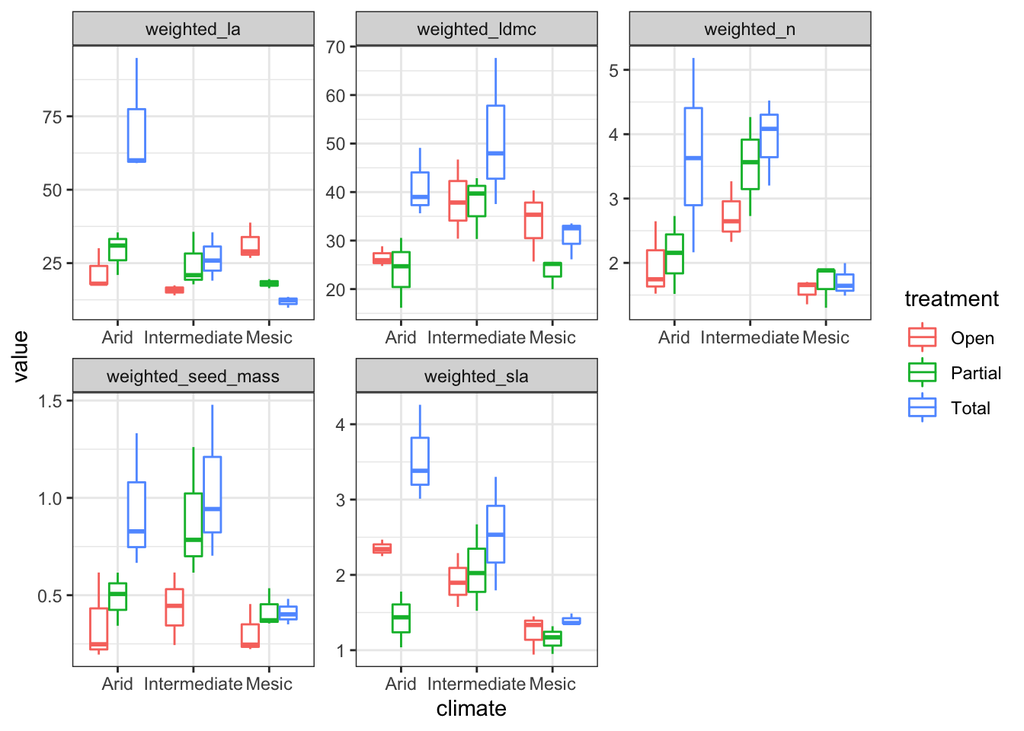

```r
cwm_traits_adj %>%
  pivot_longer(cols = weighted_la:weighted_n,
               names_to = "traits",
               values_to = "value") %>%
  ggplot(aes(x = climate, y = value, color = treatment)) +
  geom_boxplot() +
  theme_bw() +
  facet_wrap(~traits, scales = "free")
```

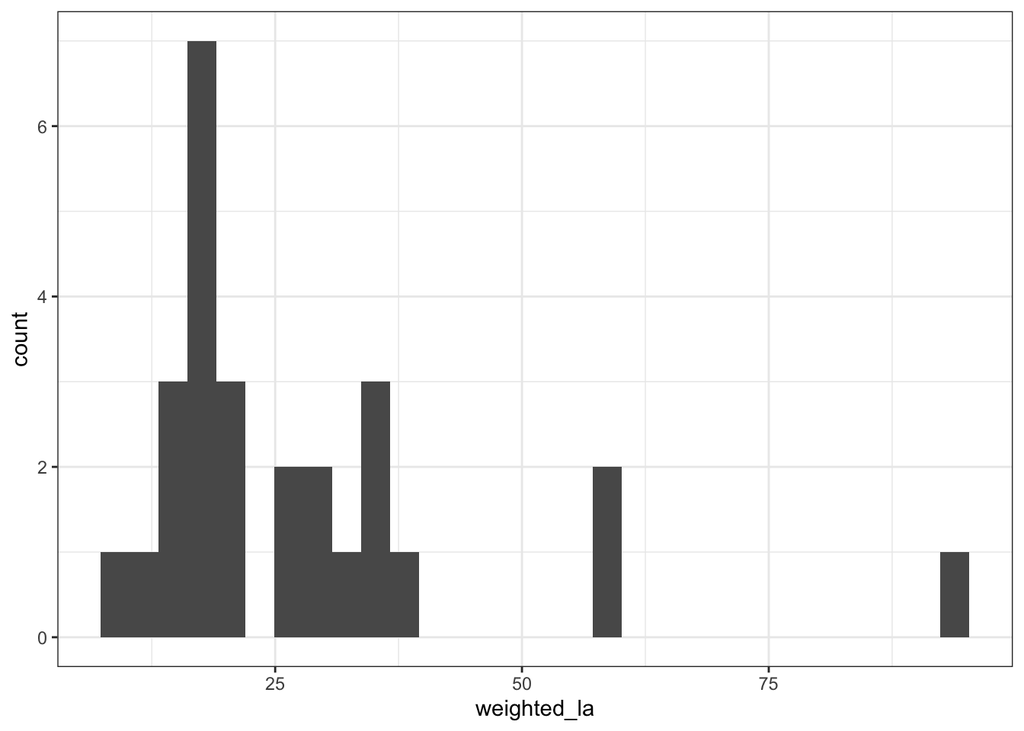

```r
ggplot(cwm_traits_adj, aes(x = weighted_la)) +
  geom_histogram() +
  theme_bw()
```

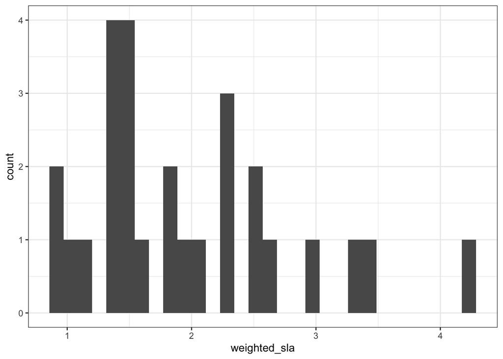

```r
ggplot(cwm_traits_adj, aes(x = weighted_sla)) +
  geom_histogram() +
  theme_bw()
```

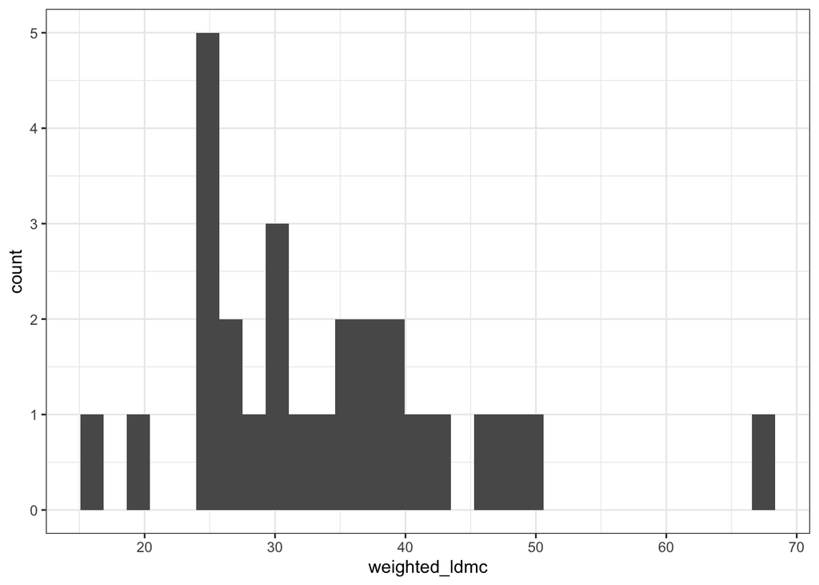

```r
ggplot(cwm_traits_adj, aes(x = weighted_ldmc)) +
  geom_histogram() +
  theme_bw()
```

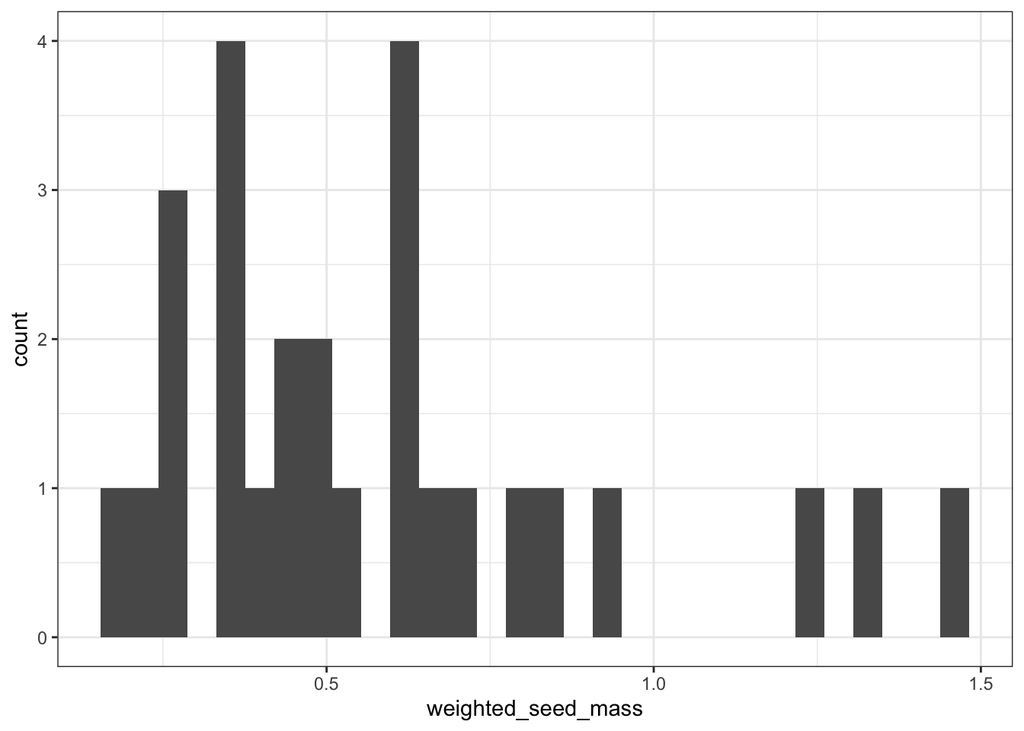

```r
ggplot(cwm_traits_adj, aes(x = weighted_seed_mass)) +
  geom_histogram() +
  theme_bw()
```

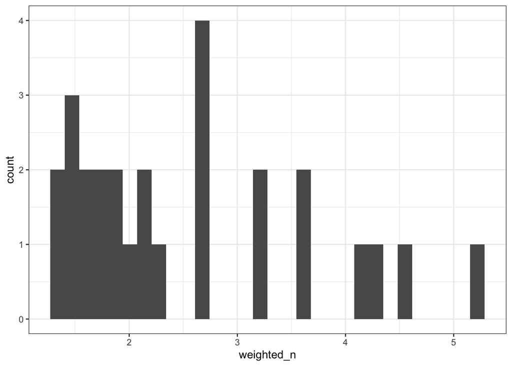

```r
ggplot(cwm_traits_adj, aes(x = weighted_n)) +
  geom_histogram() +
  theme_bw()
```

```r
# log transformation for seed mass & leaf n
cwm_traits_adj <- cwm_traits_adj %>%
  mutate(log_seed_mass = log(weighted_seed_mass)) %>%
  mutate(log_n = log(weighted_n))
```

### 2) Best-fit model:

```r
# leaf area
LA_CWM <- glmmTMB(data = cwm_traits_adj, weighted_la ~ climate * treatment, family = gaussian)
dredge(LA_CWM) #best model: weighted_la ~ climate * treatment
```

```
## Fixed terms are "cond((Int))" and "disp((Int))"
```

```
## Global model call: glmmTMB(formula = weighted_la ~ climate * treatment, data = cwm_traits_adj,
##     family = gaussian, ziformula = ~0, dispformula = ~1)
## ---
## Model selection table
##   cnd((Int)) dsp((Int)) cnd(clm) cnd(trt) cnd(clm:trt) df   logLik  AICc delta
## 8      21.94          +        +        +            + 10  -92.191 218.1  0.00
## 2      40.79          +        +                        4 -112.420 234.7 16.53
## 4      35.97          +        +        +               6 -110.089 236.4 18.25
## 1      27.91          +                                 2 -116.423 237.3 19.21
## 3      23.09          +                 +               4 -114.730 239.3 21.15
##   weight
## 8      1
## 2      0
## 4      0
## 1      0
## 3      0
## Models ranked by AICc(x)
```

```r
# SLA
SLA_CWM <- glmmTMB(data = cwm_traits_adj, weighted_sla ~ climate * treatment, family = gaussian)
dredge(SLA_CWM) #best model: weighted_sla ~ climate * treatment
```

```
## Fixed terms are "cond((Int))" and "disp((Int))"
```

```
## Global model call: glmmTMB(formula = weighted_sla ~ climate * treatment, data = cwm_traits_adj,
##     family = gaussian, ziformula = ~0, dispformula = ~1)
## ---
## Model selection table
##   cnd((Int)) dsp((Int)) cnd(clm) cnd(trt) cnd(clm:trt) df  logLik AICc delta
## 8      2.353          +        +        +            + 10 -10.304 54.4  0.00
## 4      2.318          +        +        +               6 -19.494 55.2  0.83
## 2      2.440          +        +                        4 -26.162 62.1  7.78
## 3      1.838          +                 +               4 -29.035 67.9 13.53
## 1      1.961          +                                 2 -32.733 70.0 15.61
##   weight
## 8  0.594
## 4  0.393
## 2  0.012
## 3  0.001
## 1  0.000
## Models ranked by AICc(x)
```

```r
#NEED TO DO MODEL AVERAGE

# LDMC
LDMC_CWM <- glmmTMB(data = cwm_traits_adj, weighted_ldmc ~ climate * treatment, family = gaussian)
dredge(LDMC_CWM) #best model: weighted_ldmc ~ climate + treatment
```

```
## Fixed terms are "cond((Int))" and "disp((Int))"
```

```
## Global model call: glmmTMB(formula = weighted_ldmc ~ climate * treatment, data = cwm_traits_adj,
##     family = gaussian, ziformula = ~0, dispformula = ~1)
## ---
## Model selection table
##   cnd((Int)) dsp((Int)) cnd(clm) cnd(trt) cnd(clm:trt) df   logLik  AICc delta
## 4      29.32          +        +        +               6  -91.168 198.5  0.00
## 2      30.52          +        +                        4  -97.066 203.9  5.41
## 3      32.87          +                 +               4  -98.207 206.2  7.70
## 1      34.07          +                                 2 -102.008 208.5  9.98
## 8      26.52          +        +        +            + 10  -87.871 209.5 10.96
##   weight
## 4  0.910
## 2  0.061
## 3  0.019
## 1  0.006
## 8  0.004
## Models ranked by AICc(x)
```

```r
LDMC_CWM <- glmmTMB(data = cwm_traits_adj, weighted_ldmc ~ climate + treatment, family = gaussian)

# Seed mass
seed_mass_CWM <- glmmTMB(data = cwm_traits_adj, weighted_seed_mass ~ climate * treatment, family = gaussian)
dredge(seed_mass_CWM) #best model: weighted_seed_mass ~ cliamte + treatment
```

```
## Fixed terms are "cond((Int))" and "disp((Int))"
```

```
## Global model call: glmmTMB(formula = weighted_seed_mass ~ climate * treatment, data = cwm_traits_adj,
##     family = gaussian, ziformula = ~0, dispformula = ~1)
## ---
## Model selection table
##   cnd((Int)) dsp((Int)) cnd(clm) cnd(trt) cnd(clm:trt) df logLik AICc delta
## 4     0.3726          +        +        +               6  1.639 12.9  0.00
## 3     0.3654          +                 +               4 -4.151 18.1  5.20
## 2     0.5946          +        +                        4 -4.732 19.3  6.36
## 1     0.5875          +                                 2 -8.623 21.7  8.83
## 8     0.3532          +        +        +            + 10  5.465 22.8  9.90
##   weight
## 4  0.881
## 3  0.065
## 2  0.037
## 1  0.011
## 8  0.006
## Models ranked by AICc(x)
```

```r
seed_mass_CWM <- glmmTMB(data = cwm_traits_adj, weighted_seed_mass ~ climate + treatment, family = gaussian)

# Log seed mass
log_seed_mass <- glmmTMB(data = cwm_traits_adj, log_seed_mass ~ climate * treatment, family = gaussian)
dredge(log_seed_mass) #best model: weighted_seed_mass ~ cliamte + treatment
```

```
## Fixed terms are "cond((Int))" and "disp((Int))"
```

```
## Global model call: glmmTMB(formula = log_seed_mass ~ climate * treatment, data = cwm_traits_adj,
##     family = gaussian, ziformula = ~0, dispformula = ~1)
## ---
## Model selection table
##   cnd((Int)) dsp((Int)) cnd(clm) cnd(trt) cnd(clm:trt) df  logLik AICc delta
## 4    -1.0960          +        +        +               6  -9.598 35.4  0.00
## 3    -1.1010          +                 +               4 -15.804 41.4  6.03
## 2    -0.6729          +        +                        4 -17.871 45.6 10.16
## 8    -1.1710          +        +        +            + 10  -6.750 47.3 11.85
## 1    -0.6781          +                                 2 -21.580 47.7 12.26
##   weight
## 4  0.943
## 3  0.046
## 2  0.006
## 8  0.003
## 1  0.002
## Models ranked by AICc(x)
```

```r
log_seed_mass <- glmmTMB(data = cwm_traits_adj, log_seed_mass ~ climate + treatment, family = gaussian)

# leaf nitrogen
leaf_n_CWM <- glmmTMB(data = cwm_traits_adj, weighted_n ~ climate * treatment, family = gaussian)
dredge(leaf_n_CWM) #best model: weighted_n ~ climate + treatment
```

```
## Fixed terms are "cond((Int))" and "disp((Int))"
```

```
## Global model call: glmmTMB(formula = weighted_n ~ climate * treatment, data = cwm_traits_adj,
##     family = gaussian, ziformula = ~0, dispformula = ~1)
## ---
## Model selection table
##   cnd((Int)) dsp((Int)) cnd(clm) cnd(trt) cnd(clm:trt) df  logLik AICc delta
## 4      2.136          +        +        +               6 -27.043 70.3  0.00
## 2      2.588          +        +                        4 -31.580 73.0  2.69
## 8      1.971          +        +        +            + 10 -23.453 80.7 10.37
## 1      2.549          +                                 2 -39.775 84.1 13.76
## 3      2.097          +                 +               4 -37.493 84.8 14.52
##   weight
## 4  0.789
## 2  0.205
## 8  0.004
## 1  0.001
## 3  0.001
## Models ranked by AICc(x)
```

```r
leaf_n_CWM <- glmmTMB(data = cwm_traits_adj, weighted_n ~ climate + treatment, family = gaussian)

# log leaf nitrogen
log_n_CWM <- glmmTMB(data = cwm_traits_adj, log_n ~ climate * treatment, family = gaussian)
dredge(log_n_CWM) #get: Fixed terms are "cond((Int))" and "disp((Int))"
```

```
## Fixed terms are "cond((Int))" and "disp((Int))"
```

```
## Global model call: glmmTMB(formula = log_n ~ climate * treatment, data = cwm_traits_adj,
##     family = gaussian, ziformula = ~0, dispformula = ~1)
## ---
## Model selection table
##   cnd((Int)) dsp((Int)) cnd(clm) cnd(trt) cnd(clm:trt) df  logLik AICc delta
## 4     0.7150          +        +        +               6   1.697 12.8  0.00
## 2     0.8718          +        +                        4  -2.708 15.2  2.43
## 8     0.6500          +        +        +            + 10   4.714 24.3 11.52
## 1     0.8562          +                                 2 -13.100 30.7 17.89
## 3     0.6994          +                 +               4 -11.236 32.3 19.48
##   weight
## 4  0.769
## 2  0.228
## 8  0.002
## 1  0.000
## 3  0.000
## Models ranked by AICc(x)
```

```r
log_n_CWM <- glmmTMB(data = cwm_traits_adj, log_n ~ climate + treatment, family = gaussian)

# summary figure (some info missing because not present in all glms)
# tab_model(LA_CWM, SLA_CWM, LDMC_CWM, seed_mass_CWM, leaf_n_CWM, dv.labels = c("Leaf Area CWM", "SLA CWM", "LDMC CWM", "Seed Mass CWM", "LNC CWM"))
```

### 3) Model assumptions/data distribution

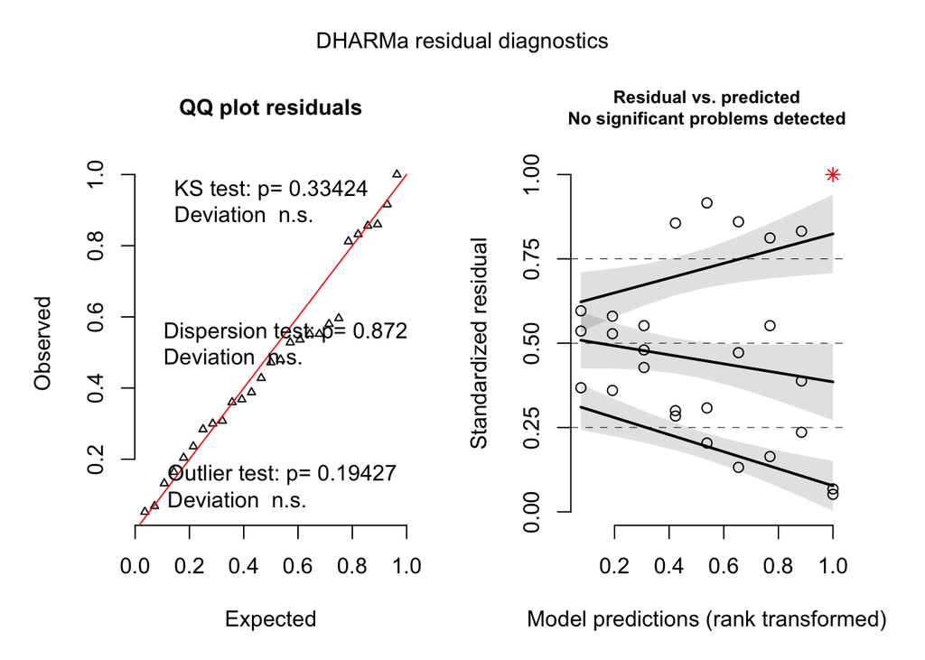

```
## Object of Class DHARMa with simulated residuals based on 250 simulations with refit = FALSE . See ?DHARMa::simulateResiduals for help.
##
## Scaled residual values: 0.3 0.284 0.856 0.164 0.812 0.552 0.052 1 0.068 0.528 0.36 0.58 0.204 0.916 0.308 0.472 0.132 0.86 0.388 0.832 ...
```

```r
# LA
simulateResiduals(LA_CWM, plot= T) #What is the red asterisk on the model predictions graph?
```

```r
shapiro.test(residuals(LA_CWM)) #normal
```

```
##
##  Shapiro-Wilk normality test
##
## data:  residuals(LA_CWM)
## W = 0.92909, p-value = 0.06564
```

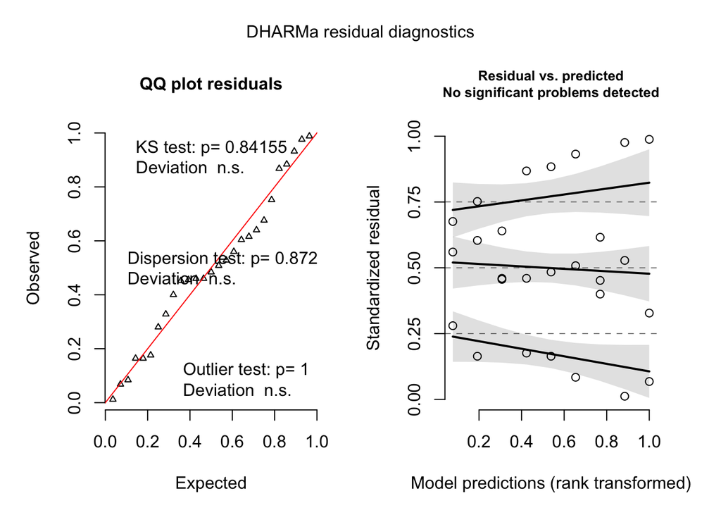

```
## Object of Class DHARMa with simulated residuals based on 250 simulations with refit = FALSE . See ?DHARMa::simulateResiduals for help.
##
## Scaled residual values: 0.4 0.616 0.452 0.176 0.868 0.46 0.328 0.988 0.068 0.484 0.164 0.884 0.084 0.932 0.508 0.528 0.012 0.976 0.604 0.752 ...
```

```r
# SLA
simulateResiduals(SLA_CWM, plot= T) #looks good
```

```r
shapiro.test(residuals(SLA_CWM)) #normal
```

```
##
##  Shapiro-Wilk normality test
##
## data:  residuals(SLA_CWM)
## W = 0.96827, p-value = 0.5569
```

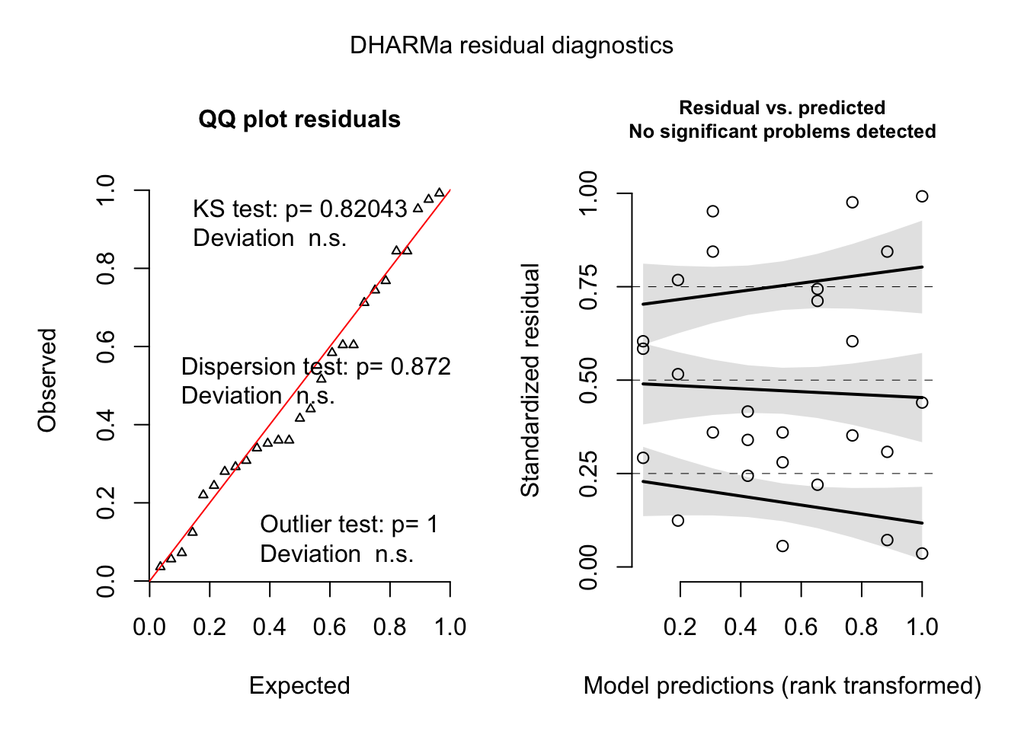

```
## Object of Class DHARMa with simulated residuals based on 250 simulations with refit = FALSE . See ?DHARMa::simulateResiduals for help.
##
## Scaled residual values: 0.34 0.244 0.416 0.124 0.516 0.768 0.604 0.976 0.352 0.308 0.072 0.844 0.22 0.744 0.712 0.44 0.036 0.992 0.844 0.952 ...
```

```r
# LDMC
simulateResiduals(LDMC_CWM, plot= T) #looks good
```

```r
shapiro.test(residuals(LDMC_CWM)) #normal
```

```
##
##  Shapiro-Wilk normality test
##
## data:  residuals(LDMC_CWM)
## W = 0.96369, p-value = 0.4468
```

```
## qu = 0.75, log(sigma) = -2.520741 : outer Newton did not converge fully.
```

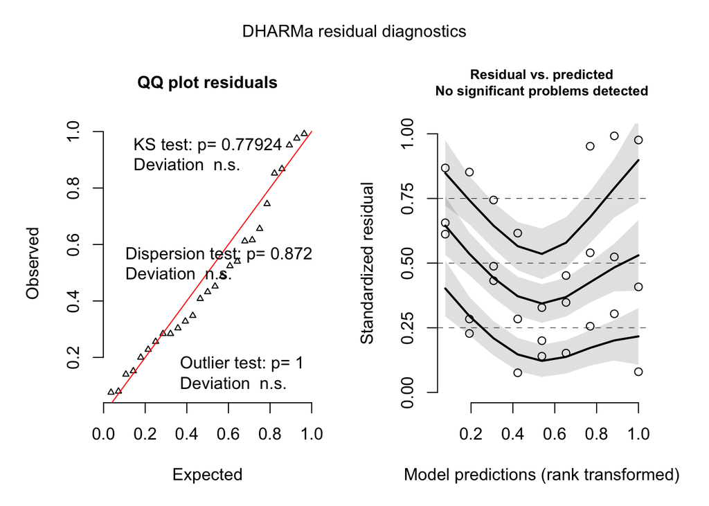

```
## Object of Class DHARMa with simulated residuals based on 250 simulations with refit = FALSE . See ?DHARMa::simulateResiduals for help.
##
## Scaled residual values: 0.228 0.284 0.852 0.152 0.348 0.452 0.304 0.992 0.524 0.616 0.076 0.284 0.256 0.952 0.54 0.408 0.08 0.976 0.656 0.612 ...
```

```r
#seed mass
simulateResiduals(seed_mass_CWM, plot= T) #model predictions look a little wonky, but it says it's good.  I'm also getting something saying that "outer Newton did not converge fully?
```

```r
shapiro.test(residuals(seed_mass_CWM)) # not normal
```

```
##
##  Shapiro-Wilk normality test
##
## data:  residuals(seed_mass_CWM)
## W = 0.91488, p-value = 0.02978
```

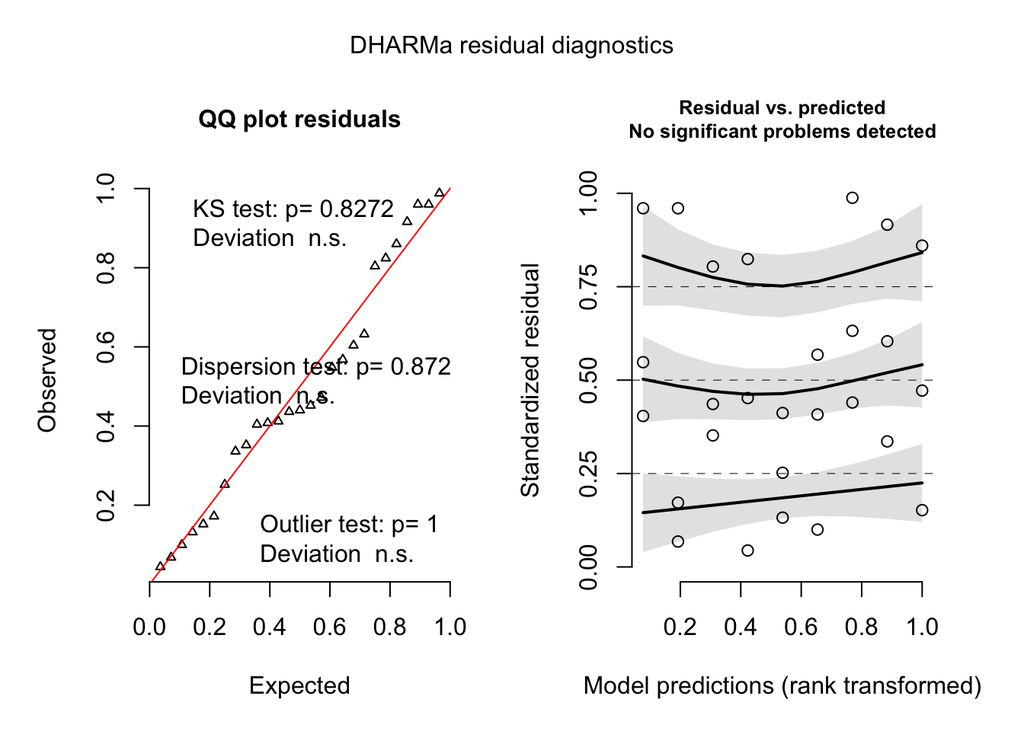

```
## Object of Class DHARMa with simulated residuals based on 250 simulations with refit = FALSE . See ?DHARMa::simulateResiduals for help.
##
## Scaled residual values: 0.068 0.172 0.96 0.1 0.408 0.568 0.44 0.988 0.632 0.824 0.044 0.452 0.336 0.916 0.604 0.472 0.152 0.86 0.548 0.404 ...
```

```r
# log seed mass
simulateResiduals(log_seed_mass, plot= T) #looks good
```

```r
shapiro.test(residuals(log_seed_mass)) #normal
```

```
##
##  Shapiro-Wilk normality test
##
## data:  residuals(log_seed_mass)
## W = 0.95695, p-value = 0.3143
```

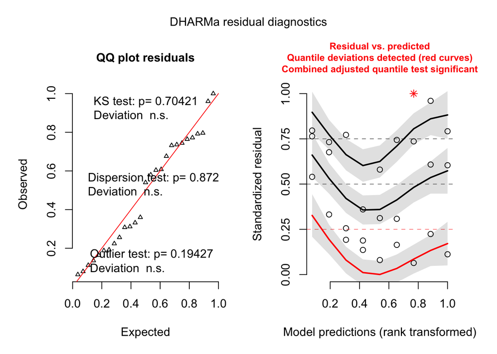

```
## Object of Class DHARMa with simulated residuals based on 250 simulations with refit = FALSE . See ?DHARMa::simulateResiduals for help.
##
## Scaled residual values: 0.192 0.256 0.772 0.08 0.312 0.58 0.064 1 0.736 0.308 0.164 0.744 0.224 0.608 0.96 0.604 0.112 0.792 0.796 0.764 ...
```

```r
# leaf n
simulateResiduals(leaf_n_CWM, plot= T) #is this good enough? one of the model predictions seems to be off
```

```r
shapiro.test(residuals(leaf_n_CWM)) #just barely not normal
```

```
##
##  Shapiro-Wilk normality test
##
## data:  residuals(leaf_n_CWM)
## W = 0.92223, p-value = 0.04469
```

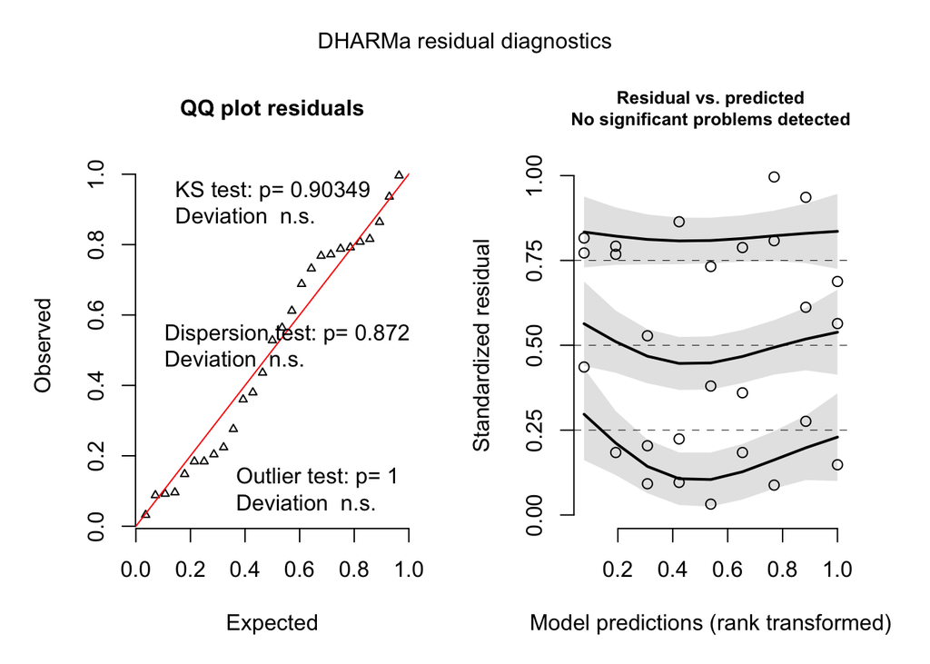

```
## Object of Class DHARMa with simulated residuals based on 250 simulations with refit = FALSE . See ?DHARMa::simulateResiduals for help.
##
## Scaled residual values: 0.096 0.224 0.864 0.032 0.38 0.732 0.088 0.996 0.808 0.36 0.184 0.788 0.276 0.612 0.936 0.564 0.148 0.688 0.816 0.772 ...
```

```r
# log_n
simulateResiduals(log_n_CWM, plot= T) #looks good?
```

```r
shapiro.test(residuals(log_n_CWM)) #normal
```

```
##
##  Shapiro-Wilk normality test
##
## data:  residuals(log_n_CWM)
## W = 0.96012, p-value = 0.3719
```

### 4. Model results & interpretation

#### 4.a. Leaf Area CWM

```r
summary(LA_CWM)
```

```
##  Family: gaussian  ( identity )
## Formula:          weighted_la ~ climate * treatment
## Data: cwm_traits_adj
##
##      AIC      BIC   logLik deviance df.resid
##    204.4    217.3    -92.2    184.4       17
##
##
## Dispersion estimate for gaussian family (sigma^2): 54.1
##
## Conditional model:
##                                      Estimate Std. Error z value Pr(>|z|)
## (Intercept)                            21.937      4.247   5.165 2.40e-07 ***
## climateIntermediate                    -6.130      6.006  -1.021   0.3074
## climateMesic                            9.577      6.006   1.595   0.1108
## treatmentPartial                        7.195      6.006   1.198   0.2309
## treatmentTotal                         49.368      6.006   8.219  < 2e-16 ***
## climateIntermediate:treatmentPartial    1.773      8.494   0.209   0.8346
## climateMesic:treatmentPartial         -20.649      8.494  -2.431   0.0151 *
## climateIntermediate:treatmentTotal    -38.393      8.494  -4.520 6.19e-06 ***
## climateMesic:treatmentTotal           -68.992      8.494  -8.122 4.58e-16 ***
## ---
## Signif. codes:  0 '***' 0.001 '**' 0.01 '*' 0.05 '.' 0.1 ' ' 1
```

```r
emmeans(LA_CWM, ~climate * treatment)
```

```
##  climate      treatment emmean   SE df lower.CL upper.CL
##  Arid         Open        21.9 4.25 17    12.98     30.9
##  Intermediate Open        15.8 4.25 17     6.85     24.8
##  Mesic        Open        31.5 4.25 17    22.55     40.5
##  Arid         Partial     29.1 4.25 17    20.17     38.1
##  Intermediate Partial     24.8 4.25 17    15.81     33.7
##  Mesic        Partial     18.1 4.25 17     9.10     27.0
##  Arid         Total       71.3 4.25 17    62.35     80.3
##  Intermediate Total       26.8 4.25 17    17.82     35.7
##  Mesic        Total       11.9 4.25 17     2.93     20.9
##
## Confidence level used: 0.95
```

```r
LA_pairs <-  as.data.frame(pairs(emmeans(LA_CWM, ~climate * treatment)))
# pairs with significance:
LA_sig_pairs <-  LA_pairs %>%
  filter(p.value <= 0.05)
```

Leaf Area CWM:

- Arid Total LA CWM larger than all other plots
- Arid:
  - Arid Total larger than both Arid Open and Arid Partial
  - No difference between Arid Open and Arid Partial
- Intermediate:
  - No difference between herbivore treatments
- Mesic:
  - No difference between herbivore treatments
- Total herbivore treatment:
  - Arid Total larger than Intermediate Total and Mesic Total
  - No difference between Int Total and Mesic Total
- No differences between Open or Partial Treatments across climates

#### 4.b. SLA CWM

```r
summary(SLA_CWM)
```

```
##  Family: gaussian  ( identity )
## Formula:          weighted_sla ~ climate * treatment
## Data: cwm_traits_adj
##
##      AIC      BIC   logLik deviance df.resid
##     40.6     53.6    -10.3     20.6       17
##
##
## Dispersion estimate for gaussian family (sigma^2): 0.126
##
## Conditional model:
##                                      Estimate Std. Error z value Pr(>|z|)
## (Intercept)                            2.3529     0.2046  11.499  < 2e-16 ***
## climateIntermediate                   -0.4329     0.2894  -1.496 0.134656
## climateMesic                          -1.1109     0.2894  -3.839 0.000124 ***
## treatmentPartial                      -0.9350     0.2894  -3.231 0.001234 **
## treatmentTotal                         1.1977     0.2894   4.139 3.49e-05 ***
## climateIntermediate:treatmentPartial   1.0879     0.4092   2.658 0.007853 **
## climateMesic:treatmentPartial          0.8396     0.4092   2.052 0.040202 *
## climateIntermediate:treatmentTotal    -0.5749     0.4092  -1.405 0.160114
## climateMesic:treatmentTotal           -1.0400     0.4092  -2.541 0.011045 *
## ---
## Signif. codes:  0 '***' 0.001 '**' 0.01 '*' 0.05 '.' 0.1 ' ' 1
```

```r
emmeans(SLA_CWM, ~climate * treatment)
```

```
##  climate      treatment emmean    SE df lower.CL upper.CL
##  Arid         Open        2.35 0.205 17    1.921     2.78
##  Intermediate Open        1.92 0.205 17    1.488     2.35
##  Mesic        Open        1.24 0.205 17    0.810     1.67
##  Arid         Partial     1.42 0.205 17    0.986     1.85
##  Intermediate Partial     2.07 0.205 17    1.641     2.50
##  Mesic        Partial     1.15 0.205 17    0.715     1.58
##  Arid         Total       3.55 0.205 17    3.119     3.98
##  Intermediate Total       2.54 0.205 17    2.111     2.97
##  Mesic        Total       1.40 0.205 17    0.968     1.83
##
## Confidence level used: 0.95
```

```r
SLA_pairs <- as.data.frame(pairs(emmeans(SLA_CWM, ~climate * treatment)))
SLA_sig_pairs <-  SLA_pairs %>%
  filter(p.value <= 0.05)
SLA_sig_pairs
```

```
##                              contrast  estimate        SE df   t.ratio
## 1              Arid,Open - Mesic,Open  1.110896 0.2893749 17  3.838951
## 2           Arid,Open - Mesic,Partial  1.206230 0.2893749 17  4.168399
## 3              Arid,Open - Arid,Total -1.197692 0.2893749 17 -4.138895
## 4      Intermediate,Open - Arid,Total -1.630594 0.2893749 17 -5.634885
## 5             Mesic,Open - Arid,Total -2.308589 0.2893749 17 -7.977846
## 6     Mesic,Open - Intermediate,Total -1.300835 0.2893749 17 -4.495329
## 7           Arid,Partial - Arid,Total -2.132645 0.2893749 17 -7.369835
## 8   Arid,Partial - Intermediate,Total -1.124892 0.2893749 17 -3.887317
## 9   Intermediate,Partial - Arid,Total -1.477658 0.2893749 17 -5.106378
## 10         Mesic,Partial - Arid,Total -2.403923 0.2893749 17 -8.307294
## 11 Mesic,Partial - Intermediate,Total -1.396169 0.2893749 17 -4.824777
## 12           Arid,Total - Mesic,Total  2.150879 0.2893749 17  7.432846
## 13   Intermediate,Total - Mesic,Total  1.143126 0.2893749 17  3.950328
##         p.value
## 1  2.741502e-02
## 2  1.427476e-02
## 3  1.513960e-02
## 4  7.709144e-04
## 5  1.081859e-05
## 6  7.419416e-03
## 7  3.075376e-05
## 8  2.492781e-02
## 9  2.184730e-03
## 10 6.257574e-06
## 11 3.832832e-03
## 12 2.754044e-05
## 13 2.201364e-02
```

```r
# plot(pairs(emmeans(SLA_CWM, ~climate * treatment))) +
#   theme_bw(base_size = 18) +
#   geom_vline(xintercept=0, size=2, color="red")
```

#### 4.c. LDMC CWM

```r
summary(LDMC_CWM)
```

```
##  Family: gaussian  ( identity )
## Formula:          weighted_ldmc ~ climate + treatment
## Data: cwm_traits_adj
##
##      AIC      BIC   logLik deviance df.resid
##    194.3    202.1    -91.2    182.3       21
##
##
## Dispersion estimate for gaussian family (sigma^2): 50.2
##
## Conditional model:
##                     Estimate Std. Error z value Pr(>|z|)
## (Intercept)           29.317      3.048   9.619  < 2e-16 ***
## climateIntermediate   11.812      3.339   3.538 0.000403 ***
## climateMesic          -1.154      3.339  -0.346 0.729678
## treatmentPartial      -4.533      3.339  -1.358 0.174611
## treatmentTotal         8.139      3.339   2.438 0.014784 *
## ---
## Signif. codes:  0 '***' 0.001 '**' 0.01 '*' 0.05 '.' 0.1 ' ' 1
```

```r
emmeans(LDMC_CWM, ~climate * treatment)
```

```
##  climate      treatment emmean   SE df lower.CL upper.CL
##  Arid         Open        29.3 3.05 21     23.0     35.7
##  Intermediate Open        41.1 3.05 21     34.8     47.5
##  Mesic        Open        28.2 3.05 21     21.8     34.5
##  Arid         Partial     24.8 3.05 21     18.4     31.1
##  Intermediate Partial     36.6 3.05 21     30.3     42.9
##  Mesic        Partial     23.6 3.05 21     17.3     30.0
##  Arid         Total       37.5 3.05 21     31.1     43.8
##  Intermediate Total       49.3 3.05 21     42.9     55.6
##  Mesic        Total       36.3 3.05 21     30.0     42.6
##
## Confidence level used: 0.95
```

```r
LDMC_pairs <- as.data.frame(pairs(emmeans(LDMC_CWM, ~climate * treatment)))
LDMC_sig_pairs <-  LDMC_pairs %>%
  filter(p.value <= 0.05)
LDMC_sig_pairs
```

```
##                                     contrast  estimate       SE df   t.ratio
## 1              Arid,Open - Intermediate,Open -11.81224 3.338820 21 -3.537849
## 2             Arid,Open - Intermediate,Total -19.95104 4.721805 21 -4.225300
## 3             Intermediate,Open - Mesic,Open  12.96599 3.338820 21  3.883404
## 4           Intermediate,Open - Arid,Partial  16.34481 4.721805 21  3.461560
## 5          Intermediate,Open - Mesic,Partial  17.49855 4.721805 21  3.705904
## 6            Mesic,Open - Intermediate,Total -21.10479 4.721805 21 -4.469644
## 7        Arid,Partial - Intermediate,Partial -11.81224 3.338820 21 -3.537849
## 8                  Arid,Partial - Arid,Total -12.67137 3.338820 21 -3.795164
## 9          Arid,Partial - Intermediate,Total -24.48361 4.721805 21 -5.185224
## 10      Intermediate,Partial - Mesic,Partial  12.96599 3.338820 21  3.883404
## 11 Intermediate,Partial - Intermediate,Total -12.67137 3.338820 21 -3.795164
## 12        Mesic,Partial - Intermediate,Total -25.63736 4.721805 21 -5.429567
## 13               Mesic,Partial - Mesic,Total -12.67137 3.338820 21 -3.795164
## 14           Arid,Total - Intermediate,Total -11.81224 3.338820 21 -3.537849
```

[output cut: 17 more lines]

```r
pairs(emmeans(LDMC_CWM, ~climate * treatment))
```

```
##  contrast                                  estimate   SE df t.ratio p.value
##  Arid,Open - Intermediate,Open              -11.812 3.34 21 -3.538  0.0411
##  Arid,Open - Mesic,Open                       1.154 3.34 21  0.346  1.0000
##  Arid,Open - Arid,Partial                     4.533 3.34 21  1.358  0.9013
##  Arid,Open - Intermediate,Partial            -7.280 4.72 21 -1.542  0.8238
##  Arid,Open - Mesic,Partial                    5.686 4.72 21  1.204  0.9467
##  Arid,Open - Arid,Total                      -8.139 3.34 21 -2.438  0.3150
##  Arid,Open - Intermediate,Total             -19.951 4.72 21 -4.225  0.0092
##  Arid,Open - Mesic,Total                     -6.985 4.72 21 -1.479  0.8528
##  Intermediate,Open - Mesic,Open              12.966 3.34 21  3.883  0.0196
##  Intermediate,Open - Arid,Partial            16.345 4.72 21  3.462  0.0482
##  Intermediate,Open - Intermediate,Partial     4.533 3.34 21  1.358  0.9013
##  Intermediate,Open - Mesic,Partial           17.499 4.72 21  3.706  0.0288
##  Intermediate,Open - Arid,Total               3.673 4.72 21  0.778  0.9964
##  Intermediate,Open - Intermediate,Total      -8.139 3.34 21 -2.438  0.3150
##  Intermediate,Open - Mesic,Total              4.827 4.72 21  1.022  0.9791
##  Mesic,Open - Arid,Partial                    3.379 4.72 21  0.716  0.9980
##  Mesic,Open - Intermediate,Partial           -8.433 4.72 21 -1.786  0.6901
##  Mesic,Open - Mesic,Partial                   4.533 3.34 21  1.358  0.9013
##  Mesic,Open - Arid,Total                     -9.293 4.72 21 -1.968  0.5791
##  Mesic,Open - Intermediate,Total            -21.105 4.72 21 -4.470  0.0053
##  Mesic,Open - Mesic,Total                    -8.139 3.34 21 -2.438  0.3150
##  Arid,Partial - Intermediate,Partial        -11.812 3.34 21 -3.538  0.0411
##  Arid,Partial - Mesic,Partial                 1.154 3.34 21  0.346  1.0000
##  Arid,Partial - Arid,Total                  -12.671 3.34 21 -3.795  0.0237
##  Arid,Partial - Intermediate,Total          -24.484 4.72 21 -5.185  0.0011
##  Arid,Partial - Mesic,Total                 -11.518 4.72 21 -2.439  0.3142
##  Intermediate,Partial - Mesic,Partial        12.966 3.34 21  3.883  0.0196
##  Intermediate,Partial - Arid,Total           -0.859 4.72 21 -0.182  1.0000
##  Intermediate,Partial - Intermediate,Total  -12.671 3.34 21 -3.795  0.0237
##  Intermediate,Partial - Mesic,Total           0.295 4.72 21  0.062  1.0000
##  Mesic,Partial - Arid,Total                 -13.825 4.72 21 -2.928  0.1377
##  Mesic,Partial - Intermediate,Total         -25.637 4.72 21 -5.430  0.0006
##  Mesic,Partial - Mesic,Total                -12.671 3.34 21 -3.795  0.0237
##  Arid,Total - Intermediate,Total            -11.812 3.34 21 -3.538  0.0411
##  Arid,Total - Mesic,Total                     1.154 3.34 21  0.346  1.0000
##  Intermediate,Total - Mesic,Total            12.966 3.34 21  3.883  0.0196
##
## P value adjustment: tukey method for comparing a family of 9 estimates
```

LDMC CWM:

- Same trend observed between all climates
- Same trend observed between all treatments
- Arid:
  - Arid-Partial < Arid-Total
  - No difference between Partial and Open
  - No difference between Total and Open
- Int:
  - Int-Partial < Int-Total
  - No difference between Partial and Open
  - No difference between Total and Open
- Mesic:
  - Mesic-Partial < Mesic-Total
  - No difference between Partial and Open
  - No difference between Total and Open
- Open treatment:
  - Int-Open > Arid-Open
  - Int-Open > Mesic-Open
  - No difference between Arid-Open and Mesic-Open
- Partial Treatment:
  - Int-Partial > Arid-Partial
  - Int-Partial > Mesic-Partial
  - No difference between Arid-Partial and Mesic-Partial
- Total Treatment:
  - Int-Total > Arid-Total
  - Int-Total > Mesic-Total
  - No difference between Arid-Total and Mesic-Total

#### 4.d. Seed mass CWM

```r
summary(log_seed_mass)
```

```
##  Family: gaussian  ( identity )
## Formula:          log_seed_mass ~ climate + treatment
## Data: cwm_traits_adj
##
##      AIC      BIC   logLik deviance df.resid
##     31.2     39.0     -9.6     19.2       21
##
##
## Dispersion estimate for gaussian family (sigma^2): 0.119
##
## Conditional model:
##                     Estimate Std. Error z value Pr(>|z|)
## (Intercept)          -1.0956     0.1486  -7.374 1.65e-13 ***
## climateIntermediate   0.3152     0.1628   1.936   0.0528 .
## climateMesic         -0.3308     0.1628  -2.032   0.0421 *
## treatmentPartial      0.5030     0.1628   3.090   0.0020 **
## treatmentTotal        0.7651     0.1628   4.701 2.59e-06 ***
## ---
## Signif. codes:  0 '***' 0.001 '**' 0.01 '*' 0.05 '.' 0.1 ' ' 1
```

```r
emmeans(log_seed_mass, ~ climate + treatment)
```

```
##  climate      treatment  emmean    SE df lower.CL upper.CL
##  Arid         Open      -1.0956 0.149 21   -1.405  -0.7867
##  Intermediate Open      -0.7805 0.149 21   -1.089  -0.4715
##  Mesic        Open      -1.4264 0.149 21   -1.735  -1.1175
##  Arid         Partial   -0.5927 0.149 21   -0.902  -0.2837
##  Intermediate Partial   -0.2775 0.149 21   -0.586   0.0315
##  Mesic        Partial   -0.9235 0.149 21   -1.232  -0.6145
##  Arid         Total     -0.3305 0.149 21   -0.639  -0.0215
##  Intermediate Total     -0.0153 0.149 21   -0.324   0.2937
##  Mesic        Total     -0.6613 0.149 21   -0.970  -0.3523
##
## Confidence level used: 0.95
```

```r
pairs(emmeans(log_seed_mass, ~ climate + treatment))
```

```
##  contrast                                  estimate    SE df t.ratio p.value
##  Arid,Open - Intermediate,Open              -0.3152 0.163 21 -1.936  0.5985
##  Arid,Open - Mesic,Open                      0.3308 0.163 21  2.032  0.5395
##  Arid,Open - Arid,Partial                   -0.5030 0.163 21 -3.090  0.1014
##  Arid,Open - Intermediate,Partial           -0.8182 0.230 21 -3.554  0.0397
##  Arid,Open - Mesic,Partial                  -0.1722 0.230 21 -0.748  0.9972
##  Arid,Open - Arid,Total                     -0.7651 0.163 21 -4.701  0.0032
##  Arid,Open - Intermediate,Total             -1.0803 0.230 21 -4.693  0.0032
##  Arid,Open - Mesic,Total                    -0.4343 0.230 21 -1.887  0.6289
##  Intermediate,Open - Mesic,Open              0.6460 0.163 21  3.969  0.0163
##  Intermediate,Open - Arid,Partial           -0.1878 0.230 21 -0.816  0.9950
##  Intermediate,Open - Intermediate,Partial   -0.5030 0.163 21 -3.090  0.1014
##  Intermediate,Open - Mesic,Partial           0.1430 0.230 21  0.621  0.9992
##  Intermediate,Open - Arid,Total             -0.4500 0.230 21 -1.955  0.5872
##  Intermediate,Open - Intermediate,Total     -0.7651 0.163 21 -4.701  0.0032
##  Intermediate,Open - Mesic,Total            -0.1192 0.230 21 -0.518  0.9998
##  Mesic,Open - Arid,Partial                  -0.8338 0.230 21 -3.622  0.0344
##  Mesic,Open - Intermediate,Partial          -1.1490 0.230 21 -4.992  0.0016
##  Mesic,Open - Mesic,Partial                 -0.5030 0.163 21 -3.090  0.1014
##  Mesic,Open - Arid,Total                    -1.0960 0.230 21 -4.761  0.0028
##  Mesic,Open - Intermediate,Total            -1.4111 0.230 21 -6.131  0.0001
##  Mesic,Open - Mesic,Total                   -0.7651 0.163 21 -4.701  0.0032
##  Arid,Partial - Intermediate,Partial        -0.3152 0.163 21 -1.936  0.5985
##  Arid,Partial - Mesic,Partial                0.3308 0.163 21  2.032  0.5395
##  Arid,Partial - Arid,Total                  -0.2622 0.163 21 -1.611  0.7889
##  Arid,Partial - Intermediate,Total          -0.5774 0.230 21 -2.508  0.2826
##  Arid,Partial - Mesic,Total                  0.0686 0.230 21  0.298  1.0000
##  Intermediate,Partial - Mesic,Partial        0.6460 0.163 21  3.969  0.0163
##  Intermediate,Partial - Arid,Total           0.0530 0.230 21  0.230  1.0000
##  Intermediate,Partial - Intermediate,Total  -0.2622 0.163 21 -1.611  0.7889
##  Intermediate,Partial - Mesic,Total          0.3838 0.230 21  1.667  0.7584
##  Mesic,Partial - Arid,Total                 -0.5930 0.230 21 -2.576  0.2536
##  Mesic,Partial - Intermediate,Total         -0.9082 0.230 21 -3.945  0.0171
##  Mesic,Partial - Mesic,Total                -0.2622 0.163 21 -1.611  0.7889
##  Arid,Total - Intermediate,Total            -0.3152 0.163 21 -1.936  0.5985
##  Arid,Total - Mesic,Total                    0.3308 0.163 21  2.032  0.5395
##  Intermediate,Total - Mesic,Total            0.6460 0.163 21  3.969  0.0163
##
## P value adjustment: tukey method for comparing a family of 9 estimates
```

#### 4.e. Leaf-N CWM

```r
summary(log_n_CWM)
```

```
##  Family: gaussian  ( identity )
## Formula:          log_n ~ climate + treatment
## Data: cwm_traits_adj
##
##      AIC      BIC   logLik deviance df.resid
##      8.6     16.4      1.7     -3.4       21
##
##
## Dispersion estimate for gaussian family (sigma^2): 0.0516
##
## Conditional model:
##                     Estimate Std. Error z value Pr(>|z|)
## (Intercept)          0.71505    0.09778   7.313 2.62e-13 ***
## climateIntermediate  0.32899    0.10712   3.071 0.002131 **
## climateMesic        -0.37597    0.10712  -3.510 0.000448 ***
## treatmentPartial     0.12815    0.10712   1.196 0.231568
## treatmentTotal       0.34219    0.10712   3.195 0.001400 **
## ---
## Signif. codes:  0 '***' 0.001 '**' 0.01 '*' 0.05 '.' 0.1 ' ' 1
```

```r
emmeans(log_n_CWM, ~climate + treatment)
```

```
##  climate      treatment emmean     SE df lower.CL upper.CL
##  Arid         Open       0.715 0.0978 21    0.512    0.918
##  Intermediate Open       1.044 0.0978 21    0.841    1.247
##  Mesic        Open       0.339 0.0978 21    0.136    0.542
##  Arid         Partial    0.843 0.0978 21    0.640    1.047
##  Intermediate Partial    1.172 0.0978 21    0.969    1.376
##  Mesic        Partial    0.467 0.0978 21    0.264    0.671
##  Arid         Total      1.057 0.0978 21    0.854    1.261
##  Intermediate Total      1.386 0.0978 21    1.183    1.590
##  Mesic        Total      0.681 0.0978 21    0.478    0.885
##
## Confidence level used: 0.95
```

```r
pairs(emmeans(log_n_CWM, ~climate + treatment))
```

```
##  contrast                                  estimate    SE df t.ratio p.value
##  Arid,Open - Intermediate,Open              -0.3290 0.107 21 -3.071  0.1051
##  Arid,Open - Mesic,Open                      0.3760 0.107 21  3.510  0.0436
##  Arid,Open - Arid,Partial                   -0.1281 0.107 21 -1.196  0.9486
##  Arid,Open - Intermediate,Partial           -0.4571 0.151 21 -3.018  0.1165
##  Arid,Open - Mesic,Partial                   0.2478 0.151 21  1.636  0.7756
##  Arid,Open - Arid,Total                     -0.3422 0.107 21 -3.195  0.0827
##  Arid,Open - Intermediate,Total             -0.6712 0.151 21 -4.431  0.0058
##  Arid,Open - Mesic,Total                     0.0338 0.151 21  0.223  1.0000
##  Intermediate,Open - Mesic,Open              0.7050 0.107 21  6.581  <.0001
##  Intermediate,Open - Arid,Partial            0.2008 0.151 21  1.326  0.9122
##  Intermediate,Open - Intermediate,Partial   -0.1281 0.107 21 -1.196  0.9486
##  Intermediate,Open - Mesic,Partial           0.5768 0.151 21  3.808  0.0231
##  Intermediate,Open - Arid,Total             -0.0132 0.151 21 -0.087  1.0000
##  Intermediate,Open - Intermediate,Total     -0.3422 0.107 21 -3.195  0.0827
##  Intermediate,Open - Mesic,Total             0.3628 0.151 21  2.395  0.3358
##  Mesic,Open - Arid,Partial                  -0.5041 0.151 21 -3.328  0.0634
##  Mesic,Open - Intermediate,Partial          -0.8331 0.151 21 -5.500  0.0005
##  Mesic,Open - Mesic,Partial                 -0.1281 0.107 21 -1.196  0.9486
##  Mesic,Open - Arid,Total                    -0.7182 0.151 21 -4.741  0.0029
##  Mesic,Open - Intermediate,Total            -1.0471 0.151 21 -6.913  <.0001
##  Mesic,Open - Mesic,Total                   -0.3422 0.107 21 -3.195  0.0827
##  Arid,Partial - Intermediate,Partial        -0.3290 0.107 21 -3.071  0.1051
##  Arid,Partial - Mesic,Partial                0.3760 0.107 21  3.510  0.0436
##  Arid,Partial - Arid,Total                  -0.2140 0.107 21 -1.998  0.5605
##  Arid,Partial - Intermediate,Total          -0.5430 0.151 21 -3.585  0.0372
##  Arid,Partial - Mesic,Total                  0.1619 0.151 21  1.069  0.9728
##  Intermediate,Partial - Mesic,Partial        0.7050 0.107 21  6.581  <.0001
##  Intermediate,Partial - Arid,Total           0.1149 0.151 21  0.759  0.9969
##  Intermediate,Partial - Intermediate,Total  -0.2140 0.107 21 -1.998  0.5605
##  Intermediate,Partial - Mesic,Total          0.4909 0.151 21  3.241  0.0755
##  Mesic,Partial - Arid,Total                 -0.5900 0.151 21 -3.895  0.0191
##  Mesic,Partial - Intermediate,Total         -0.9190 0.151 21 -6.067  0.0001
##  Mesic,Partial - Mesic,Total                -0.2140 0.107 21 -1.998  0.5605
##  Arid,Total - Intermediate,Total            -0.3290 0.107 21 -3.071  0.1051
##  Arid,Total - Mesic,Total                    0.3760 0.107 21  3.510  0.0436
##  Intermediate,Total - Mesic,Total            0.7050 0.107 21  6.581  <.0001
##
## P value adjustment: tukey method for comparing a family of 9 estimates
```

## Functional Diveristy

- Need to make datasheets in correct format for FD package